# Communities and Crime: Final Assignment

Emma Haapa

3 maaliskuuta 2017

# Abstract

This Course diary is related to the final assignment for the purpose of the course Introduction to Open Data Science of University of Helsinki, spring 2017. My aim was to explore and analyze the Communities and Crime in the US communities, as described in the upcoming passages. During the investigation I performed Primary Component Analysis on the data to reduce it’s dimensions and see the relationships more clearly, and based on that as well as my own hypotheses and assumptions I fitted a Linear Model on the data. Using some socio-economic and population related variables as explanatory variables I attempted to predict the total number of violent crimes per 100 000 population in the US communities, resulting in a linear model that explains 45 percent of the total variability in violent crimes. The percentage of African American people of the population seemed to be the most highly impacting variable in my model, but as opposed to how I predicted, immigration, income and the use of public transport related variables had less impact on the violent crimes variable.

# PCA and Linear regression on Communities and Crime dataset

[figure not shown]

The aim of this assignment is to perform both Primary Component Analysis and lLnear Regression on the “Communities and crime”" dataset found in the [UCI Machine Learning Repository](https://archive.ics.uci.edu/ml/datasets/Communities+and+Crime+Unnormalized#) and validate the produced model through the model validation process introduced during the course. My initial hypothesis is that at least the racial profile of the community and number of homeless people, as well as some employment status and immigration related variables, could have a relationship with the number of violent crimes per population.

## The Communities and Crime data

The data is the unnormalized version of the [Communities and crime data set](https://archive.ics.uci.edu/ml/datasets/Communities+and+Crime+Unnormalized#) of Michael Redmond for Computer Science in La Salle University, Philadelphia, PA, USA. It describes the different aspects of crime and socio economic surroundings containing variables that might affect the crime rate in the U.S. communities. The dataset includes socio economic data from 1990 US Census, crime data from 1995 US FBI Uniform Crime Report and law enforcement data from 1990 US Law Enforcement Management and Administrative Statistics Survey (LEMAS), available from ICPSR at University of Michigan. The number of oservations in this dataset is 2215 and there are in total 147 variables, of which 18 - for example the total number of of violent crimes per population and the total number of non-violent crimes per population - are considered possible target variables to be predicted, and 5 non-predicive variables, such as state, county, community and community name. The rest of the variables are considered predictive variables, among them for example the percentage of blacks in the community, the percentage of working moms and the number of officers assigned to special drug units.

The population and the sum of all crimes considered violent was used in calculating the goal variable, per capita violent crimes. The interesting part in this process, according to the UCI Machine learning repository’s data information page, was that there was controversy as to which kind of crimes diffeent states considered violent, which in turn led to numerous missing values in the data. Nearly all cities regarded murder, robbery, and assault as violent crimes, but some cities in midwestern states did not consider it necessary to add rape to this list, hence they were not included in the final Communities and crime data set. Before omitting those cities the “rapes” column had multiple missing values and that consequently resulted in misinterpreted values for the target variable.

As the process of this exploration went on, I noticed it turned out to include a multitude of missing values. In order to delve into Primary Component Analysis with regard to this data, I came into the conclusion of performing na.omit on the data in the process of doing this exercise. Furthermore, I decided to choose the unnormalized data set instead of the normalized version, also available in the UCI repository, because the values in the data matrix seemed to be more easily comprehensible and comparable, whereas in the normalized data set all od the values were in the range of 0 to 1. What is more, the normalization performed on the data, I was afraid, would have left some extreme observations out. I learned that while performing linear regression, no standardization or normalization is essentially necessary, since the parameters and their signifigance is relatively the same whether performed on a standardized or an unstandardized data set. However, as normalization on the data was easy to perform I did it for the data and saved the data in a different file, but in the further summarizing explorations I will look at the unnormalized data because of the aforementioned reasons of the values being more easily comprehensible and comparable.

As for why I chose this particular data set out of all the ones available in UCI machine learning repository alone, there are many reasons. First of all, I wanted to have a look on a different data to all of the sets we explored durng the course, and see what I could do on my own. Secondly, but notof inferior importance, I am very interested in crime related data in general, and the relationships of different aspects of population and socio economic variables affecting the crime rate especially in the US. This was only further accelerated by the glimpse we had on a data set called Boston (included in the MASS package of the R software) during the IODS course, however, I felt like I wanted to have a more widespread look on the crime in the US - and as I stumbled uppon the Communities and Crime data set, it felt like the perfect one to go on an explore in my final project.

## The data wrangling process on the Communities and Crime data

The data available in the UCI repository didn’t contain names for the variables at all; they were only given in the description of the data in a list with descriptions of the variables included. Accordingly, before any data wrangling could be done, I created a list of column names in a separate .txt-file where I removed all other information in the variables list found on the data information page. In the R scrip where the data wrangling was done, i then assigned the column names in the data to be taken from this columnnames.txt-data, that I saved into a separate object.

The actual data wrangling process for this data can be found in this [link to my GitHub repository](https://github.com/emhaapa/IODS-final/blob/master/DataWrangling2.R). The process consisted of removing columns with numerous missing values and omitting some non-predictive variables that are not of interest in building a linear regression model (those included for example county, community and community name). Furthermore, in the finalized data set I only kept some interesting variables that I hypothesized to have some kind of significant effect on the total crime variable and which I determined didn’t contain so many missing values as for example the LEMAS- and police related variables, and performed na.omit() on the data to get rid of the missing values. The variables in the data set, accompanied with their descriptions found on the [data information page](https://archive.ics.uci.edu/ml/datasets/Communities+and+Crime+Unnormalized#) in the following list, are:

- **“ViolentCrimesPerPop”** = total number of violent crimes per 100K population
- **“population”** = population for community
- **“PctForeignBorn”** = percent of people foreign born
- **“NumInShelters”** = number of people in homeless shelters
- **“NumStreet”** = number of homeless people counted in the street
- **“PctHomeless”** = number of homeless people in homeless shelters plus homeless in the street divided by population times 100
- **“PopDens”** = population density in persons per square mile
- **“perCapInc”** = per capita income
- **“medIncome”** = median household income
- **“PctLess9thGrade”** = percentage of people 25 and over with less than a 9th grade education
- **“PctRecentImmig”** = percent of population who have immigrated within the last 3 years
- **“racepctblack”** = percentage of population that is african american
- **“PctEmploy”** = percentage of people 16 and over who are employed
- **“MalePctNevMarr”** = percentage of males who have never married
- **“PctWorkMom”** = percentage of moms of kids under 18 in labor force
- **“PctPopUnderPov”** = percentage of people under the poverty level
- **“PctPersDenseHous”** = percent of persons in dense housing (more than 1 person per room)
- **“PctUsePubTrans”** = percent of people using public transit for commuting

As a side note, among all other interesting variables not included in the final data set, there was also a variable in the original data called **“RacialMatchCommPol”** = a measure of the racial match between the community and the police force, high values indicate proportions in community and police force are similar, which initially seemed quite interesting in terms of analysis. However, I decided not to include it in my wrangled data set as it contained a high number of missing values and in the end didn’t seem to provide any information for some of the communities included in the data.

I also wanted the row names of this data to be distinctified by the community names followed by the state column’s character string indicating in which state this community is in, so I assigned the row names to be taken from those two columns and subsequently removed them from the dataset. The more tidy and comprehensible data set resulting from this data wrangling I called CommunityCrime22.

## Looking into the data: plots and tables

First off, let’s have a peek at the latter, smaller data with the variables mentioned in the preceding list through tables and plots.

```r
# Accessing libraries:
library(gmodels)
library(gdata)
library(dplyr)
library(ggplot2)
library(readr)
library(tidyr)
library(tidyverse)
library(corrplot)
library(GGally)
library(stringr)

options(max.print=1000000)

CommunityCrime22 <- read.table('CommunityCrime22.txt', sep=",", header = TRUE)
CommunityCrime22n <- read.table('CommunityCrime221.txt', sep=",", header = TRUE) # Normalized data

head(rownames(CommunityCrime22), 10)
```

```
##  [1] "BerkeleyHeightstownship,NJ" "Marpletownship,PA"
##  [3] "Tigardcity,OR"              "Gloversvillecity,NY"
##  [5] "Springfieldcity,MO"         "Norwoodtown,MA"
##  [7] "Andersoncity,IN"            "Fargocity,ND"
##  [9] "Wacocity,TX"                "Shermancity,TX"
```

As we can see from the initial exploration done with R’s head()- and rownames()-functions, the row names actually do correspond with the communities in question.

```r
str(CommunityCrime22)
```

```
## 'data.frame':    1994 obs. of  18 variables:
##  $ ViolentCrimesPerPop: num  41 128 219 307 443 ...
##  $ population         : int  11980 23123 29344 16656 140494 28700 59459 74111 103590 31601 ...
##  $ PctForeignBorn     : num  10.66 8.3 5 2.04 1.49 ...
##  $ PctHomeless        : num  0.09 0 0.05 0 0.24 0 0.04 0.19 0.05 0 ...
##  $ PopDens            : num  1846 2187 2781 3218 1996 ...
##  $ perCapInc          : int  29711 20148 16946 10810 11878 18193 12161 13554 10195 12929 ...
##  $ PctUsePubTrans     : num  9.63 3.84 4.37 3.31 0.97 9.62 0.7 1.41 0.76 0 ...
##  $ PctLess9thGrade    : num  5.81 5.61 2.8 11.05 8.76 ...
##  $ PctRecentImmig     : num  0.93 0.43 0.82 0.28 0.32 1.05 0.11 0.47 0.72 0.53 ...
##  $ NumInShelters      : int  11 0 16 0 327 0 21 125 43 1 ...
##  $ racepctblack       : num  1.37 0.8 0.74 1.7 2.51 ...
##  $ PctEmploy          : num  64.5 62 69.8 54.7 59 ...
##  $ MalePctNevMarr     : num  26.4 28 25.8 28.1 33.3 ...
##  $ PctWorkMom         : num  58.9 62.4 74.2 70.3 70.5 ...
##  $ PctPopUnderPov     : num  1.96 3.98 4.75 17.23 17.78 ...
##  $ NumStreet          : int  0 0 0 0 4 0 0 15 4 0 ...
##  $ medIncome          : int  75122 47917 35669 20580 21577 42805 23221 25326 17852 24763 ...
##  $ PctPersDenseHous   : num  0.39 1.01 2.03 1.21 2.11 1.47 1.9 1.67 6.14 3.41 ...
```

```r
glimpse(CommunityCrime22)
```

```
## Observations: 1,994
## Variables: 18
## $ ViolentCrimesPerPop <dbl> 41.02, 127.56, 218.59, 306.64, 442.95, 226...
## $ population          <int> 11980, 23123, 29344, 16656, 140494, 28700,...
## $ PctForeignBorn      <dbl> 10.66, 8.30, 5.00, 2.04, 1.49, 9.19, 0.87,...
## $ PctHomeless         <dbl> 0.09, 0.00, 0.05, 0.00, 0.24, 0.00, 0.04, ...
## $ PopDens             <dbl> 1845.9, 2186.7, 2780.9, 3217.7, 1995.7, 26...
## $ perCapInc           <int> 29711, 20148, 16946, 10810, 11878, 18193, ...
## $ PctUsePubTrans      <dbl> 9.63, 3.84, 4.37, 3.31, 0.97, 9.62, 0.70, ...
## $ PctLess9thGrade     <dbl> 5.81, 5.61, 2.80, 11.05, 8.76, 4.49, 10.09...
## $ PctRecentImmig      <dbl> 0.93, 0.43, 0.82, 0.28, 0.32, 1.05, 0.11, ...
## $ NumInShelters       <int> 11, 0, 16, 0, 327, 0, 21, 125, 43, 1, 20, ...
## $ racepctblack        <dbl> 1.37, 0.80, 0.74, 1.70, 2.51, 1.60, 14.20,...
## $ PctEmploy           <dbl> 64.55, 61.96, 69.80, 54.74, 59.02, 65.42, ...
## $ MalePctNevMarr      <dbl> 26.38, 27.99, 25.78, 28.15, 33.32, 36.05, ...
## $ PctWorkMom          <dbl> 58.88, 62.43, 74.19, 70.27, 70.52, 72.81, ...
## $ PctPopUnderPov      <dbl> 1.96, 3.98, 4.75, 17.23, 17.78, 4.01, 17.9...
## $ NumStreet           <int> 0, 0, 0, 0, 4, 0, 0, 15, 4, 0, 49, 2, 0, 1...
## $ medIncome           <int> 75122, 47917, 35669, 20580, 21577, 42805, ...
## $ PctPersDenseHous    <dbl> 0.39, 1.01, 2.03, 1.21, 2.11, 1.47, 1.90, ...
```

We can also have a look at which kind of values the included variables get with str()- and glimpse()-functions: mostly numerical values. Let’s now look at the summary of the data:

```r
summary(CommunityCrime22)
```

```
##  ViolentCrimesPerPop   population      PctForeignBorn    PctHomeless
##  Min.   :   0.0      Min.   :  10005   Min.   : 0.180   Min.   :0.0000
##  1st Qu.: 161.7      1st Qu.:  14359   1st Qu.: 2.080   1st Qu.:0.0000
##  Median : 374.1      Median :  22681   Median : 4.490   Median :0.0000
##  Mean   : 589.1      Mean   :  52251   Mean   : 7.606   Mean   :0.0735
##  3rd Qu.: 794.4      3rd Qu.:  43154   3rd Qu.: 9.585   3rd Qu.:0.0900
##  Max.   :4877.1      Max.   :7322564   Max.   :60.400   Max.   :2.1100
##     PopDens        perCapInc     PctUsePubTrans   PctLess9thGrade
##  Min.   :   10   Min.   : 5237   Min.   : 0.000   Min.   : 0.200
##  1st Qu.: 1171   1st Qu.:11548   1st Qu.: 0.350   1st Qu.: 4.770
##  Median : 1996   Median :13977   Median : 1.220   Median : 7.920
##  Mean   : 2790   Mean   :15522   Mean   : 3.063   Mean   : 9.444
##  3rd Qu.: 3270   3rd Qu.:17775   3rd Qu.: 3.377   3rd Qu.:12.245
##  Max.   :44230   Max.   :63302   Max.   :54.330   Max.   :49.890
##  PctRecentImmig   NumInShelters       racepctblack     PctEmploy
##  Min.   : 0.000   Min.   :    0.00   Min.   : 0.00   Min.   :24.82
##  1st Qu.: 0.180   1st Qu.:    0.00   1st Qu.: 0.94   1st Qu.:56.35
##  Median : 0.530   Median :    0.00   Median : 3.15   Median :62.27
##  Mean   : 1.149   Mean   :   67.72   Mean   : 9.51   Mean   :61.78
##  3rd Qu.: 1.370   3rd Qu.:   24.00   3rd Qu.:11.96   3rd Qu.:67.50
##  Max.   :13.710   Max.   :23383.00   Max.   :96.67   Max.   :84.67
##  MalePctNevMarr    PctWorkMom    PctPopUnderPov     NumStreet
##  Min.   :12.06   Min.   :41.95   Min.   : 0.640   Min.   :    0.00
##  1st Qu.:25.41   1st Qu.:64.96   1st Qu.: 4.692   1st Qu.:    0.00
##  Median :29.00   Median :69.25   Median : 9.650   Median :    0.00
##  Mean   :30.67   Mean   :68.80   Mean   :11.796   Mean   :   18.71
##  3rd Qu.:33.47   3rd Qu.:73.34   3rd Qu.:17.078   3rd Qu.:    1.00
##  Max.   :76.32   Max.   :89.37   Max.   :48.820   Max.   :10447.00
##    medIncome      PctPersDenseHous
##  Min.   : 11576   Min.   : 0.050
##  1st Qu.: 23597   1st Qu.: 1.300
##  Median : 30896   Median : 2.470
##  Mean   : 33699   Mean   : 4.325
##  3rd Qu.: 41215   3rd Qu.: 4.920
##  Max.   :123625   Max.   :59.490
```

We can see from the summary table that the values of violent crimes per population range from zero to almost 5 000 with a median at around 374, which tells us that there is variation between cities: some of them have a high rate of violent crimes whereas some of the cities don’t seem to have violent crimes at all (minimum at zero). This is more easy to detect in the unnormalized version of the data, since the values are actual numbers of violent crimes instead of something between 0 and 1.

From the summary of the population column it can be concluded that the data included small communities with as little as 10 005 in population, and also very large communities with a high number of people going up to over 7,3 million. This also affects the population density, which varies from 10 persons per square mile to a staggering 44 230 persons per square mile. What is interesting in the percent of foreign born people -column, is that it varies significantly: some communities have only 0,18 percent of foreign born recidents whereas the maximum is as high as 60,4 percent - more than a half of the people are foreign born in some communities. The same goes for racepctblack, the percent of people of African American heritage: the minimum is a straight zero, the median and mean are both quite low, but the maximum is 96,67 (!), extremely high.

Let’s look at the distributions and correlations more visually with ggpairs() and corrplot(), and let’s also draw a pair-matrix of the normalized data set, just for fun:

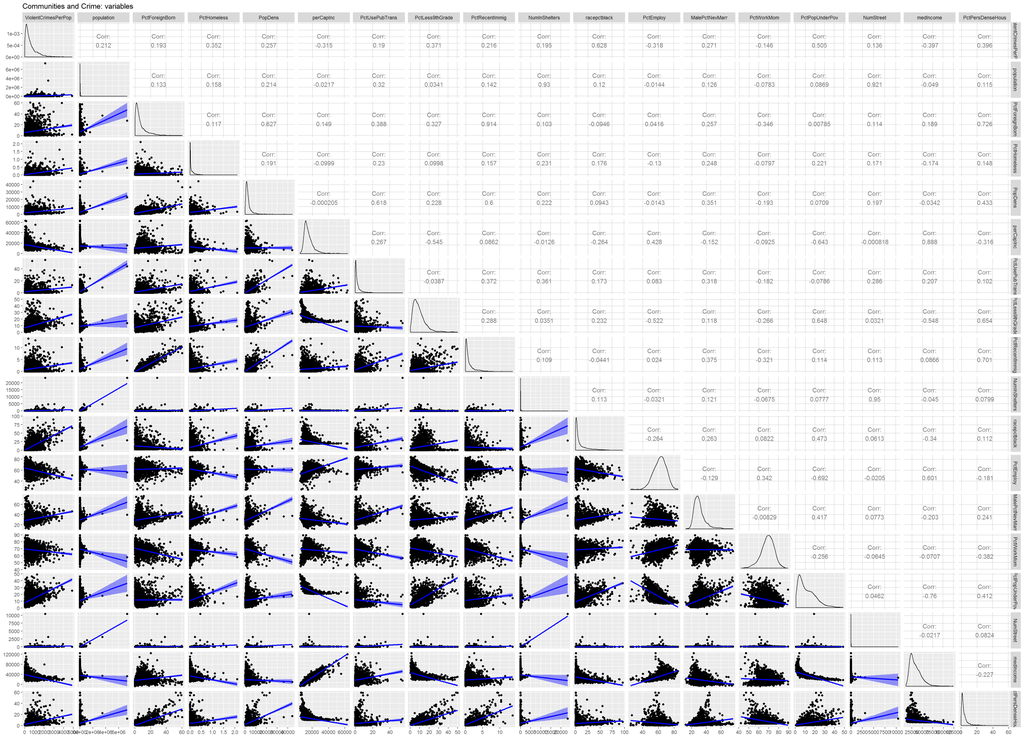

```r
library(GGally)
library(ggplot2)
library(clusterSim)


lines1 <- function(data, mapping, ...){
  p <- ggplot(data = data, mapping = mapping) +
    geom_point() +
    geom_smooth(method=lm, fill="blue", color="blue", ...)
  p
}


g = ggpairs(CommunityCrime22, lower = list(continuous = lines1))
p1 <- g + ggtitle("Communities and Crime: variables")
p1
```

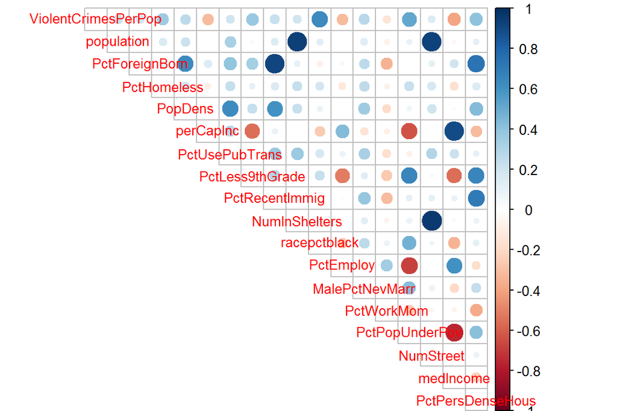

```r
corrplot(round(cor(CommunityCrime22n), digits = 2), method = "circle", type = "upper", tl.pos = "d", tl.cex = 0.8)
```

## PCA on the Community and Crime data

Next, to reduce the dimensionality of this data set, I’ll move on to perform Primary Component Analysis (PCA) on it. A Principal Component Analysis (abbreviated as PCA) can be conducted on the dataset to lower its dimensionality using the singular value decomposition (SVD) method. The SVD literally decomposes a matrix and produces a product of smaller matrices, which brings out the most important components, and in statistics, PCA aims to do exactly that. It represents the data at hand in two dimensions with respect to Principal components - the components which explain different proportions of variance of the original variables, or in other words, features. The first Principal component always explains the largest proportion of variance along the features, and the importance of the PC is relative to the order in which it is represented in the PCA: for example, PC2 explains the second largest proportion of variance and PC3 the third largest and so on. Usually only two principal components explain the most significant amount of variance, hece the two-dimensionality of the PCA and the resulting biplot (bi = two) with arrows representing the correlation between the variables with each other and with the two PCs. Consequently, the Principal components are also uncorrelated, which means that the angle between them is 90 degrees (which corresponds to a 0 correlation).

To do that we need to convert the data set into a data frame and scale it - otherwise the skewed distributions of the variables and the differing variances would lead PCA to “perceive” the variables with larger variance as also more important, because PCA is impacted by the scaling of the features.

```r
library(clusterSim)
CommunityCrime22111_s <- as.data.frame(scale(CommunityCrime22n))

summary(CommunityCrime22111_s)
```

```
##  ViolentCrimesPerPop   population       PctForeignBorn
##  Min.   :-0.9582     Min.   :-0.20899   Min.   :-0.8537
##  1st Qu.:-0.6952     1st Qu.:-0.18745   1st Qu.:-0.6353
##  Median :-0.3497     Median :-0.14628   Median :-0.3582
##  Mean   : 0.0000     Mean   : 0.00000   Mean   : 0.0000
##  3rd Qu.: 0.3340     3rd Qu.:-0.04501   3rd Qu.: 0.2275
##  Max.   : 6.9748     Max.   :35.96538   Max.   : 6.0694
##   PctHomeless         PopDens          perCapInc       PctUsePubTrans
##  Min.   :-0.4885   Min.   :-0.9519   Min.   :-1.6516   Min.   :-0.61715
##  1st Qu.:-0.4885   1st Qu.:-0.5544   1st Qu.:-0.6381   1st Qu.:-0.54663
##  Median :-0.4885   Median :-0.2718   Median :-0.2481   Median :-0.37133
##  Mean   : 0.0000   Mean   : 0.0000   Mean   : 0.0000   Mean   : 0.00000
##  3rd Qu.: 0.1097   3rd Qu.: 0.1646   3rd Qu.: 0.3618   3rd Qu.: 0.06338
##  Max.   :13.5352   Max.   :14.1909   Max.   : 7.6729   Max.   :10.32968
##  PctLess9thGrade   PctRecentImmig    NumInShelters       racepctblack
##  Min.   :-1.3507   Min.   :-0.6971   Min.   :-0.11652   Min.   :-0.6744
##  1st Qu.:-0.6830   1st Qu.:-0.5878   1st Qu.:-0.11652   1st Qu.:-0.6077
##  Median :-0.2227   Median :-0.3754   Median :-0.11652   Median :-0.4510
##  Mean   : 0.0000   Mean   : 0.0000   Mean   : 0.00000   Mean   : 0.0000
##  3rd Qu.: 0.4092   3rd Qu.: 0.1344   3rd Qu.:-0.07522   3rd Qu.: 0.1741
##  Max.   : 5.9098   Max.   : 7.6240   Max.   :40.12028   Max.   : 6.1807
##    PctEmploy        MalePctNevMarr      PctWorkMom       PctPopUnderPov
##  Min.   :-4.55793   Min.   :-2.2980   Min.   :-4.07473   Min.   :-1.3110
##  1st Qu.:-0.66905   1st Qu.:-0.6493   1st Qu.:-0.58193   1st Qu.:-0.8348
##  Median : 0.06075   Median :-0.2066   Median : 0.06958   Median :-0.2522
##  Mean   : 0.00000   Mean   : 0.0000   Mean   : 0.00000   Mean   : 0.0000
##  3rd Qu.: 0.70638   3rd Qu.: 0.3461   3rd Qu.: 0.68922   3rd Qu.: 0.6207
##  Max.   : 2.82333   Max.   : 5.6380   Max.   : 3.12261   Max.   : 4.3509
##    NumStreet          medIncome       PctPersDenseHous
##  Min.   :-0.07304   Min.   :-1.6520   Min.   :-0.7331
##  1st Qu.:-0.07304   1st Qu.:-0.7544   1st Qu.:-0.5188
##  Median :-0.07304   Median :-0.2093   Median :-0.3181
##  Mean   : 0.00000   Mean   : 0.0000   Mean   : 0.0000
##  3rd Qu.:-0.06913   3rd Qu.: 0.5612   3rd Qu.: 0.1020
##  Max.   :40.70308   Max.   : 6.7150   Max.   : 9.4595
```

```r
pcaCC2211_std <- prcomp(CommunityCrime22111_s) # Perform the PCA.
sumpcaCC2211_std <- summary(pcaCC2211_std) # Summarise the results.
sumpcaCC2211_std # Print summary.
```

```
## Importance of components:
##                           PC1    PC2    PC3     PC4     PC5     PC6
## Standard deviation     2.2422 1.8963 1.6275 1.22696 1.04483 0.93150
## Proportion of Variance 0.2793 0.1998 0.1472 0.08363 0.06065 0.04821
## Cumulative Proportion  0.2793 0.4791 0.6262 0.70987 0.77052 0.81873
##                            PC7     PC8     PC9    PC10    PC11    PC12
## Standard deviation     0.90364 0.82539 0.63321 0.60089 0.50595 0.49249
## Proportion of Variance 0.04536 0.03785 0.02228 0.02006 0.01422 0.01347
## Cumulative Proportion  0.86409 0.90194 0.92422 0.94428 0.95850 0.97197
##                           PC13    PC14    PC15    PC16    PC17    PC18
## Standard deviation     0.38973 0.35187 0.27531 0.24847 0.22126 0.20569
## Proportion of Variance 0.00844 0.00688 0.00421 0.00343 0.00272 0.00235
## Cumulative Proportion  0.98041 0.98729 0.99150 0.99493 0.99765 1.00000
```

As we can see from the previous table, the Proportions of variance for the two first primary components (0,2793 and 0,1998) do not look very promising - essentially, the two first primary components explain less than half of the total variance - but let’s continue on to drawing the biplot of this result.

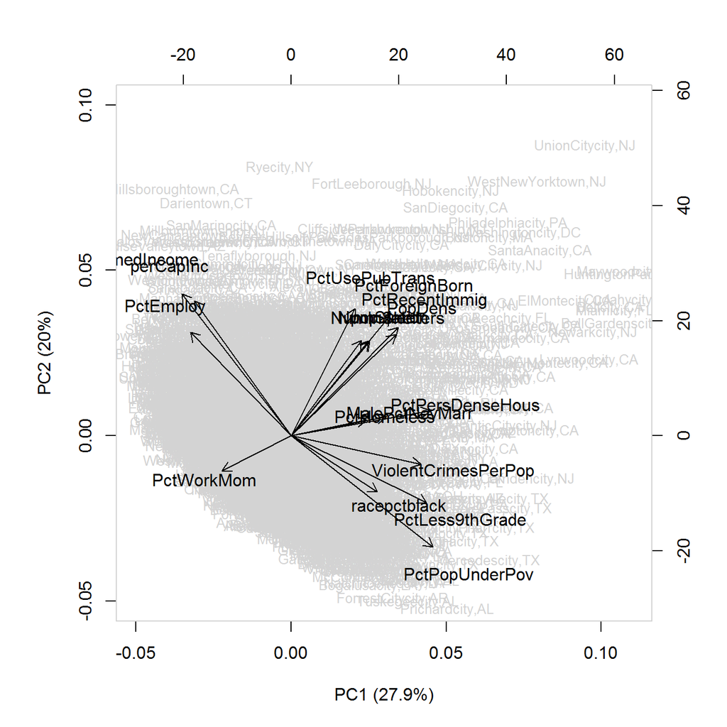

```r
# Extract percentages of variance from the summary (for the plot titles).
pr_CC2211s <- round(100*sumpcaCC2211_std$importance[2, ], digits = 1)
pc_CC2211_lab <- paste0(names(pr_CC2211s), " (", pr_CC2211s, "%)") # Create plot axis titles.
# Plot
biplot(pcaCC2211_std, cex = c(0.8, 1), col = c("LightGray", "black"), xlab = pc_CC2211_lab[1], ylab = pc_CC2211_lab[2], xlim=c(-0.05, 0.11), ylim=c(-0.05, 0.1))
```

With the initial settings the plot wasn’t exactly readable; because of the quite remarkable outliers (New York, for example) that made the scale of the x- and y-axii very wide. That’s why I used xlim and ylim to limit the range of the axii and produce a more readable biplot. Now, from the above plot we can see from the direction of the arrows, which features contribute to either of the primary components. Clearly, percent of people in dense housing, percent of male persons never married, percent of homeless as well as violent crimes per population (our target variable for linear regression) percent of people with lower than or 9th grade education and percent of African Amrican of the population correlate with the first principal component. Also percent of working moms with under 18 year old kids seems to fall in this category, however, the arrow points to the opposite direction. Features that contribute to both of the first primary components but might contribute more to the PC2, are percent of people under poverty rate, median and per capita income and percent of employed people, which all have to do with income related aspects. These include also percent of people using public transport, percent of recently immigrated of population, number of homeless in the streets and in shelters, population and population density - population related features which also have to do with income. Furthermore, the angle between a single feature and the PC-axis can be interpreted as the correlation between these two, a small angle indicating strong positive correlation. The arrows which are in a close to 90 degrees angle with either PC1 or PC2 have close to a 0 correlation with these PCs, so only for percent of people in dense housing, percent of male persons never married, percent of homeless as well as violent crimes per population we can say for sure they are in almost no correlation with PC2, having only a small angle with PC1.

## Thoughts and hypotheses

From the Primary Component Analysis conducted in the previous passage, as well as from my own initial hypotheses, I concluded that I could attempt to fit the linear model based on the following variables:

- **“ViolentCrimesPerPop”** = total number of violent crimes per 100K population (as the target variable, to be explained)
- **“PctHomeless”** = number of homeless people in homeless shelters plus homeless in the street divided by population times 100 **OR**
- **“NumStreet”** = number of homeless people counted in the street
- **“perCapInc”** = per capita income
- **“PctLess9thGrade”** = percentage of people 25 and over with less than a 9th grade education
- **“racepctblack”** = percentage of population that is african american
- **“PctEmploy”** = percentage of people 16 and over who are employed
- **“MalePctNevMarr”** = percentage of males who have never married
- **“PctWorkMom”** = percentage of moms of kids under 18 in labor force
- **“PctPopUnderPov”** = percentage of people under the poverty level
- **“PctPersDenseHous”** = percent of persons in dense housing (more than 1 person per room)

My hypothesis at this point is that all of the above variables have a significant linear relationship with the target variable.

## Linear regression on the dataset

Linear regression provides a means to create simple statistical models that attempt to explain the relationship between a target variable and one or more explanatory variables, called simple regression and multiple regression, respectively. The linear model explains only a linear relationship between the variables, not any other kind of relationship or correlation, which encourages me to attempt to fit a model on this data despite the low correlations. The idea in the interpretation of the model is to look at the parameters - the intercept, which is called the alpha-parameter, and the “slope” which is called the beta-parameter and can be interpreted as the coefficient of the linear dependency between the explanatory variable and the target variable.

The summary table of the soon fitted models includes a value called **R-squared** - it is a statistical measure of how close the data are to the fitted regression line. It is also known as ‘the coefficient of determination’, or ‘the coefficient of multiple determination’ for multiple regression, as in this case. By definition, R-squared is the percentage of the response variable variation that is explained by a linear model. In other words: how well the model explains the main variables variation, as opposed to other factors that might affect the main variable. It can be written as

*R-squared = Explained variation / total variation*

R-squared is always between 0 and 100%: If R-squared is 0% that indicates the model explains none of the variability of the response data around its mean. If R-squared is 100% that indicates that the model explains all the variability of the response data around its mean.

In general, the higher the R-squared, the better.

The validation of the soon produced model tackles the assumptions, on which the model is based - these include for example the normality and constant variance of the errors. The linear model in R can be fitted with lm()-function and the parameters of the model can be read from the summary-table produced by the regular summary-function:

```r
library(ggplot2)
library(GGally)

# create a regression model with multiple explanatory variables
model0 <- lm(ViolentCrimesPerPop ~ racepctblack + PctHomeless + PctEmploy + PctWorkMom + PctPersDenseHous + PctPopUnderPov + perCapInc + MalePctNevMarr+  PctLess9thGrade, data = CommunityCrime22)

# print out a summary of the model
summary(model0)
```

```
##
## Call:
## lm(formula = ViolentCrimesPerPop ~ racepctblack + PctHomeless +
##     PctEmploy + PctWorkMom + PctPersDenseHous + PctPopUnderPov +
##     perCapInc + MalePctNevMarr + PctLess9thGrade, data = CommunityCrime22)
##
## Residuals:
##      Min       1Q   Median       3Q      Max
## -1460.02  -188.46   -62.04   135.62  2706.32
##
## Coefficients:
##                    Estimate Std. Error t value Pr(>|t|)
## (Intercept)      883.016605 169.469484   5.210 2.08e-07 ***
## racepctblack      23.088469   0.774607  29.807  < 2e-16 ***
## PctHomeless      812.074894  64.046164  12.680  < 2e-16 ***
## PctEmploy         -4.277643   1.763300  -2.426  0.01536 *
## PctWorkMom        -4.799691   1.830730  -2.622  0.00882 **
## PctPersDenseHous  29.704165   2.438596  12.181  < 2e-16 ***
## PctPopUnderPov     4.354673   2.352293   1.851  0.06428 .
## perCapInc         -0.004296   0.002212  -1.942  0.05229 .
## MalePctNevMarr    -1.355178   1.390496  -0.975  0.32988
## PctLess9thGrade   -5.329430   2.356492  -2.262  0.02383 *
## ---
## Signif. codes:  0 '***' 0.001 '**' 0.01 '*' 0.05 '.' 0.1 ' ' 1
##
## Residual standard error: 410.1 on 1984 degrees of freedom
## Multiple R-squared:  0.5571, Adjusted R-squared:  0.555
## F-statistic: 277.2 on 9 and 1984 DF,  p-value: < 2.2e-16
```

We can see from the summary-table that this initial approach didn’t produce parameters corresponding to the variables that would all statistically significantly differ from zero. We can see that from the p-value column of the summary table: the statistical test produced p-values that aren’t significant on any common significancy level, represented by * (stars) in the end of the rows. The statistical test related to the parameters is namely a test for the null-hypothesis that the beta-parameter in the regression model is actually zero. The p-value indicates the probability of that happening, using this statistical model. The influence of an explanatory variable is statistically significant, if it (in general) is <0,05. The highest value the p-value could take to be statistically at least somewhat significant, is 0,1.

```r
# create a regression model with multiple explanatory variables
model1 <- lm(ViolentCrimesPerPop ~ racepctblack + PctHomeless + PctEmploy + PctWorkMom + PctPersDenseHous + PctPopUnderPov + MalePctNevMarr+  PctLess9thGrade, data = CommunityCrime22)

# print out a summary of the model
summary(model1)
```

```
##
## Call:
## lm(formula = ViolentCrimesPerPop ~ racepctblack + PctHomeless +
##     PctEmploy + PctWorkMom + PctPersDenseHous + PctPopUnderPov +
##     MalePctNevMarr + PctLess9thGrade, data = CommunityCrime22)
##
## Residuals:
##      Min       1Q   Median       3Q      Max
## -1495.62  -185.50   -61.31   136.10  2719.45
##
## Coefficients:
##                  Estimate Std. Error t value Pr(>|t|)
## (Intercept)      702.7933   141.8977   4.953 7.93e-07 ***
## racepctblack      22.8867     0.7681  29.795  < 2e-16 ***
## PctHomeless      811.6787    64.0905  12.665  < 2e-16 ***
## PctEmploy         -4.3758     1.7638  -2.481  0.01319 *
## PctWorkMom        -3.2916     1.6590  -1.984  0.04738 *
## PctPersDenseHous  30.2681     2.4229  12.492  < 2e-16 ***
## PctPopUnderPov     6.5112     2.0751   3.138  0.00173 **
## MalePctNevMarr    -1.8604     1.3669  -1.361  0.17365
## PctLess9thGrade   -4.7556     2.3395  -2.033  0.04221 *
## ---
## Signif. codes:  0 '***' 0.001 '**' 0.01 '*' 0.05 '.' 0.1 ' ' 1
##
## Residual standard error: 410.4 on 1985 degrees of freedom
## Multiple R-squared:  0.5562, Adjusted R-squared:  0.5544
## F-statistic:   311 on 8 and 1985 DF,  p-value: < 2.2e-16
```

```r
# create a regression model with multiple explanatory variables
model2 <- lm(ViolentCrimesPerPop ~ racepctblack + PctHomeless + PctEmploy + PctWorkMom + PctPersDenseHous +  PctLess9thGrade, data = CommunityCrime22)

# print out a summary of the model
summary(model2)
```

```
##
## Call:
## lm(formula = ViolentCrimesPerPop ~ racepctblack + PctHomeless +
##     PctEmploy + PctWorkMom + PctPersDenseHous + PctLess9thGrade,
##     data = CommunityCrime22)
##
## Residuals:
##      Min       1Q   Median       3Q      Max
## -1465.16  -191.20   -68.43   135.10  2686.64
##
## Coefficients:
##                  Estimate Std. Error t value Pr(>|t|)
## (Intercept)      881.1912   124.8270   7.059 2.30e-12 ***
## racepctblack      23.7269     0.7059  33.611  < 2e-16 ***
## PctHomeless      820.8594    63.0700  13.015  < 2e-16 ***
## PctEmploy         -7.1761     1.5100  -4.752 2.15e-06 ***
## PctWorkMom        -3.5850     1.6501  -2.173   0.0299 *
## PctPersDenseHous  30.4174     2.3451  12.971  < 2e-16 ***
## PctLess9thGrade   -2.0852     2.1615  -0.965   0.3348
## ---
## Signif. codes:  0 '***' 0.001 '**' 0.01 '*' 0.05 '.' 0.1 ' ' 1
##
## Residual standard error: 411.2 on 1987 degrees of freedom
## Multiple R-squared:  0.554,  Adjusted R-squared:  0.5527
## F-statistic: 411.4 on 6 and 1987 DF,  p-value: < 2.2e-16
```

```r
# create a regression model with multiple explanatory variables
model3 <- lm(ViolentCrimesPerPop ~ racepctblack + PctHomeless + PctEmploy + PctWorkMom + PctPersDenseHous, data = CommunityCrime22)

# print out a summary of the model
summary(model3)
```

```
##
## Call:
## lm(formula = ViolentCrimesPerPop ~ racepctblack + PctHomeless +
##     PctEmploy + PctWorkMom + PctPersDenseHous, data = CommunityCrime22)
##
## Residuals:
##     Min      1Q  Median      3Q     Max
## -1450.1  -190.2   -67.8   133.6  2691.2
##
## Coefficients:
##                  Estimate Std. Error t value Pr(>|t|)
## (Intercept)      837.0238   116.1261   7.208 8.04e-13 ***
## racepctblack      23.6824     0.7044  33.621  < 2e-16 ***
## PctHomeless      825.4129    62.8921  13.124  < 2e-16 ***
## PctEmploy         -6.3946     1.2743  -5.018 5.68e-07 ***
## PctWorkMom        -3.8343     1.6297  -2.353   0.0187 *
## PctPersDenseHous  28.9000     1.7394  16.615  < 2e-16 ***
## ---
## Signif. codes:  0 '***' 0.001 '**' 0.01 '*' 0.05 '.' 0.1 ' ' 1
##
## Residual standard error: 411.2 on 1988 degrees of freedom
## Multiple R-squared:  0.5538, Adjusted R-squared:  0.5527
## F-statistic: 493.5 on 5 and 1988 DF,  p-value: < 2.2e-16
```

```r
# create a regression model with multiple explanatory variables / change the PctHomeless into NumStreet and PctPersDenseHous with MalePctNevMarr
model4 <- lm(ViolentCrimesPerPop ~ racepctblack + NumStreet + PctEmploy + PctWorkMom + MalePctNevMarr, data = CommunityCrime22)

# print out a summary of the model
summary(model4)
```

```
##
## Call:
## lm(formula = ViolentCrimesPerPop ~ racepctblack + NumStreet +
##     PctEmploy + PctWorkMom + MalePctNevMarr, data = CommunityCrime22)
##
## Residuals:
##      Min       1Q   Median       3Q      Max
## -1682.79  -253.94   -78.17   159.55  2679.09
##
## Coefficients:
##                  Estimate Std. Error t value Pr(>|t|)
## (Intercept)    1563.32637  123.84792  12.623  < 2e-16 ***
## racepctblack     25.51783    0.78335  32.575  < 2e-16 ***
## NumStreet         0.19455    0.03987   4.879 1.15e-06 ***
## PctEmploy        -7.25917    1.40453  -5.168 2.60e-07 ***
## PctWorkMom      -14.51211    1.67415  -8.668  < 2e-16 ***
## MalePctNevMarr    7.37851    1.30438   5.657 1.77e-08 ***
## ---
## Signif. codes:  0 '***' 0.001 '**' 0.01 '*' 0.05 '.' 0.1 ' ' 1
##
## Residual standard error: 453 on 1988 degrees of freedom
## Multiple R-squared:  0.4584, Adjusted R-squared:  0.457
## F-statistic: 336.5 on 5 and 1988 DF,  p-value: < 2.2e-16
```

**Summaries of the models**

|  | *Dependent variable:* |  |  |  |  |
| --- | --- | --- | --- | --- | --- |
|  | ViolentCrimesPerPop |  |  |  |  |
|  | model 0 | model 1 | model 2 | model 3 | model 4 |
|  | (1) | (2) | (3) | (4) | (5) |
| racepctblack | 23.088*** (0.775) | 22.887*** (0.768) | 23.727*** (0.706) | 23.682*** (0.704) | 25.518*** (0.783) |
| PctHomeless | 812.075*** (64.046) | 811.679*** (64.091) | 820.859*** (63.070) | 825.413*** (62.892) |  |
| NumStreet |  |  |  |  | 0.195*** (0.040) |
| PctEmploy | -4.278** (1.763) | -4.376** (1.764) | -7.176*** (1.510) | -6.395*** (1.274) | -7.259*** (1.405) |
| PctWorkMom | -4.800*** (1.831) | -3.292** (1.659) | -3.585** (1.650) | -3.834** (1.630) | -14.512*** (1.674) |
| PctPersDenseHous | 29.704*** (2.439) | 30.268*** (2.423) | 30.417*** (2.345) | 28.900*** (1.739) |  |
| PctPopUnderPov | 4.355* (2.352) | 6.511*** (2.075) |  |  |  |
| perCapInc | -0.004* (0.002) |  |  |  |  |
| MalePctNevMarr | -1.355 (1.390) | -1.860 (1.367) |  |  | 7.379*** (1.304) |
| PctLess9thGrade | -5.329** (2.356) | -4.756** (2.340) | -2.085 (2.161) |  |  |
| Constant | 883.017*** (169.469) | 702.793*** (141.898) | 881.191*** (124.827) | 837.024*** (116.126) | 1,563.326*** (123.848) |
| Observations | 1,994 | 1,994 | 1,994 | 1,994 | 1,994 |
| R<sup>2</sup> | 0.557 | 0.556 | 0.554 | 0.554 | 0.458 |
| Adjusted R<sup>2</sup> | 0.555 | 0.554 | 0.553 | 0.553 | 0.457 |
| Residual Std. Error | 410.091 (df = 1984) | 410.377 (df = 1985) | 411.187 (df = 1987) | 411.180 (df = 1988) | 453.023 (df = 1988) |
| F Statistic | 277.235*** (df = 9; 1984) | 310.984*** (df = 8; 1985) | 411.377*** (df = 6; 1987) | 493.484*** (df = 5; 1988) | 336.478*** (df = 5; 1988) |
| *Note:* | p<0.1; p<0.05; p<0.01 |  |  |  |  |

The beta-parameter can be viewed as the slope of the curve which indicates the influence of this variable on the target variable. Reading from the summary table, the beta parameter for the first variable, percent of African American of the population, is 25,5, which means that when the african american population increases by one, the violent crimes increase by 25,5. This is a significant linear relationship, clearly, and could be intuitively thought of, at least based on the image the media produces of the state of the crime statistics in the U.S. It could be concluded that in areas with more African american people there are also more violent crimes per population.

The number of homeless found in the streets also has an influence on the target variable. The influence is not so strong as the previous variables’, but still positive: when number of homeless in the streets increases by one the violent crimes increases by 0,19. There is of course no causality to be read from linear models, so we do not know which of the variables causes the increase in which variable, but seemingly in communities with more homeless people in the streets there is also more violent crime present.

As opposed to racepctblack and NumStreets, the next two variables have a significant negative linear impact on the target variable. It seems that when percent of employed of the population increases one unit, violent crime per population decreases by roughly seven units, since the beta-parameter is negative. Same goes for the percent of mothers of under 18-year old kids who are in work force; the decreasing impact on violent crime is -14,5 when percent of working moms increases. It is also very intuitive: unemployment might add to crime whereas being employment provides people with income and more stable living conditions. Also some other conclusions could be drawn, but they might be a bit off limits considering this is just linear regression - for example about the cultural backgrounds in which women and mothers choose to work and whether it could be a factor that affects the linear impact on violent crime.

The percent of male who have never been married has a positive beta-parameter of 7,4, which says that the unit increase in the share of men who have never married increases total number of violent crimes per population by 7,4 units. This could have many sorts of interpretations, of which one could be that single men could be more prone to commit violent crimes - or that in communities where there’s a high number of violent crimes, also the men are single and not in stable relationships (marriage). For example in rural areas and small communities, men might be married and heads of the families, whereas in urban areas there would be more single men, say, gang members and such.

To have a look at the single variables influence on the target variable, lets draw plots:

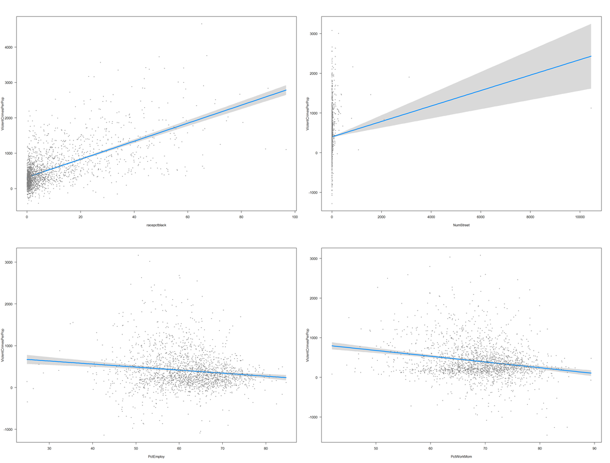

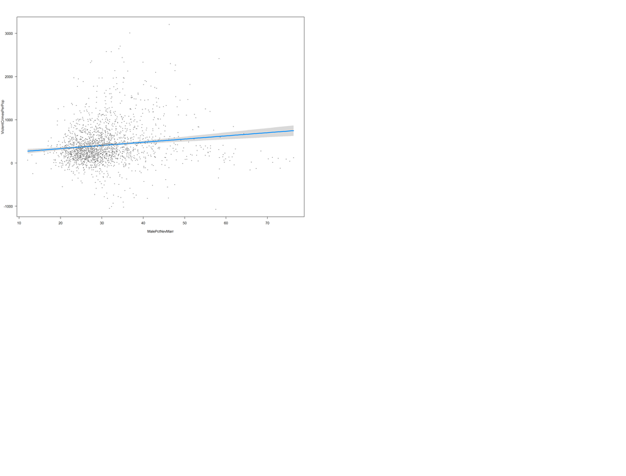

```r
library(visreg)
par(mfrow = c(2,2))
visreg(model4)
```

These figures proved to be very visual: for example the outliers in the NumStreet can be seen to affect the model fit’s slope very significantly.

Let’s move onto model validation to look at how well the assumptions of the linear model hold in case of this particular model.

## Model validation

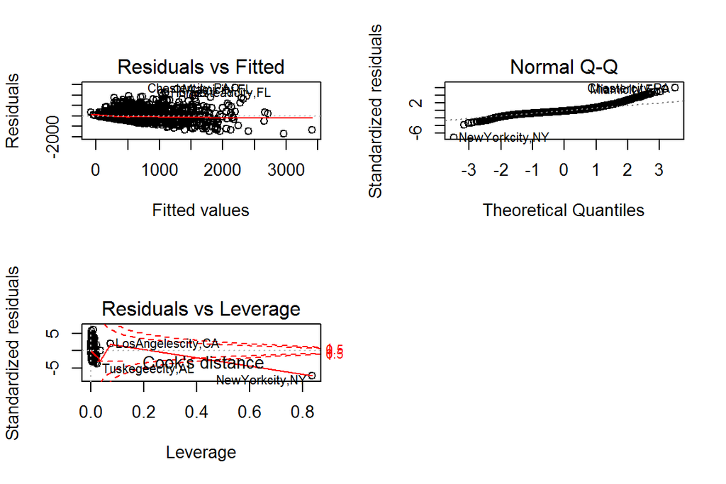

```r
par(mfrow= c(2,2))
plot(model4, which=c(1:2,5))
```

In linear regression the assumptions include that the target variable is assumed to be a linear combination of the explanatory variables - i. e. the fisrt big assumption associated with a linear model is linearity. Generally, it is useful to assume also, that the errors are normally distributed and moreover, with a mean of 0 and a constant variance. This includes also the notion that the errors are not correlated and that the size of an error does not depend on the explanatory variables. There are a number of graphical ways to explore these assumptions, for example:

**The Residuals vs. Fitted values -plot**

The Residuals vs. Fitted values -plot explores the constant variance assumption of the errors in the model, in other words the assumption that there should be no or close to none dependency between the errors and the explanatory variables. The simple plot shows residuals and model predictions; if there seems to be any pattern in the plot, ir could be concluded that there is some dependency present and the variance of the errors is not constant.

In the plot of the model, the points seem to be distributed a little skewedly - the points range seems to widen from left to right, from dense to points with larger distances. The curve fitted to these points is rather horizontal, but with a little deviation, which points to a dependency of the errors on the explanatory variables. In this case, I would say that the variance might not necessarily be constant, and this assumption of the linear model could be questioned.

## Conclusions violent crime

While the dataset in itself is interesting, and the investigation in this course diary did prove to be at least entertaining, it seems that the exploration of this data provides some problems and leaves room for further processing. The problems aside, in the linear model finally fitted, it was found that the racepctblack, NumStreet, PctEmploy, PctWorkMom and MalePctNevMarr have a significant linear relationship with the violent crimes per population variable, which to me seemed interesting. Intuitive, for some part, but before conducting the analysis I would not have thought that for example percent of male persons who have never married would be in connection with violent crimes. It was maybe too intuitive to think of, as it was a little bit surprising to find out that the percent of employed people and mothers had a decresing impact on violent crimes - first I thought of homeless people being a much better indicator.

As for the problems, even though the linear model fitted based on the Primary Component Analysis results seemed promising at first, it turned out to produce quite skewed diagnostic plots and thus was not validated to sufficiently fulfill the assumptions of a linear model. Perhaps fitting the linear model on unnormalized dataset was a bad idea after all, seeing the significant outliers affecting the model diagnostics remarkably. The missing values also seemed to be a problem in case of Communities and Crime data, as some of the columns contained substantial amounts of NAs compared to the others and performing na.omit() on the whole dataset would have lead to roughly 200 observations. Accordingly, in the data wrangling phase of the process, I hold onto my will of preserving as many observations as possible from the original data in the wrangled data, as I believed choosing only a non-representative subset of all the observations I could be left with totally unrelated conclusions that have nothing to do with the original data. It also drove me to choose variables that had fewer missing values - whether there were more imfluencible variables in the data (policeforce-related variables perhaps) that could have explained more of the variability in the target variable, is left unknown. This is a good point for further analysis - or a reason for me to delve into the data once again.

## Citations:

Some citation requirements mentioned in the data information page of the UCI Machine Learning Repository:

- U. S. Department of Commerce, Bureau of the Census, Census Of Population And Housing 1990 United States: Summary Tape File 1a & 3a (Computer Files),
- U.S. Department Of Commerce, Bureau Of The Census Producer, Washington, DC and Inter-university Consortium for Political and Social Research Ann Arbor, Michigan. (1992)
- U.S. Department of Justice, Bureau of Justice Statistics, Law Enforcement Management And Administrative Statistics (Computer File) U.S. Department Of Commerce, Bureau Of The Census Producer, Washington, DC and Inter-university Consortium for Political and Social Research Ann Arbor, Michigan. (1992)
- U.S. Department of Justice, Federal Bureau of Investigation, Crime in the United States (Computer File) (1995)
- As a final remark, I couldn’t find how to produce captions in knitr or rmarkdown (as I first didn’t know what that part of instructions meant and as I realized it, it was already too late) so I sincerely hope my work would suffice like this. -